# 0. Introduction

We aim to develop a robust model to mitigate credit risk for MoneyLion, acting as a crucial intermediary between loan applications and funding decisions.

### Problem Overview:

The primary challenge faced by MoneyLion is assessing the risk of loan default, a critical aspect of lending operations. Whether it's an individual seeking a personal loan or a corporation requesting financial assistance, accurately predicting the likelihood of loan default is paramount to mitigate financial losses and maintain a healthy lending portfolio.

### Business Perspective:

MoneyLion operates within a dual landscape: approving loans with a high probability of successful repayment while minimizing exposure to default risk. Positive outcomes include revenue generation from interest payments, while defaults lead to financial losses. Striking the right balance is essential: rejecting low-risk applicants means lost revenue opportunities, while approving high-risk ones amplifies the risk of defaults.

### Objectives:

Our primary objective is clear: develop a predictive model that effectively identifies loans at risk of default. By leveraging historical loan data, we aim to train a model capable of distinguishing between loans likely to be repaid and those prone to default. This model will serve as a critical tool in the loan approval process, providing MoneyLion with actionable insights to make informed lending decisions.

### Approach:

Our proposed approach involves utilizing machine learning techniques to analyze historical loan data and identify key predictors of default. By training a binary classification model, we can predict the likelihood of default for each loan application, enabling MoneyLion to assess risk and make data-driven lending decisions.

In summary, our solution aims to empower MoneyLion with the ability to proactively manage credit risk, thereby safeguarding their financial interests and ensuring the sustainability of their lending operations.

## Import necessary libraries.

```python
#data wrangling
import math
import pandas as pd
import numpy as np

# Data visualization
import seaborn as sns
import matplotlib.pyplot as plt
from matplotlib.ticker import PercentFormatter

#  preprocessing
from dateutil import parser
from sklearn import preprocessing

#Scaling
from sklearn.preprocessing import StandardScaler

#Model training
from sklearn.model_selection import StratifiedKFold, GridSearchCV, train_test_split
from imblearn.over_sampling import SMOTE
from sklearn.linear_model import LogisticRegression
from sklearn.metrics import accuracy_score, confusion_matrix, precision_score, recall_score, f1_score, roc_curve, roc_auc_score
import xgboost as xgb
```

# 1. Reading datasets and First look

Go through each dataset one by one to understand how the data is organized and make sure it's well-structured.

```python
#read the datasets into seperate dataframes
loan_df = pd.read_csv('loan.csv', parse_dates=['applicationDate', 'originatedDate'])
payment_df = pd.read_csv('payment.csv', parse_dates=['paymentDate'])
clarity_df = pd.read_csv('clarity_underwriting_variables.csv')
```

### Exploring the loan.csv

```python
# Check first few rows of each DataFrame
loan_df.head()
```

|  | loanId | anon_ssn | payFrequency | apr | applicationDate | originated | originatedDate | nPaidOff | approved | isFunded | loanStatus | loanAmount | originallyScheduledPaymentAmount | state | leadType | leadCost | fpStatus | clarityFraudId | hasCF |
| --- | --- | --- | --- | --- | --- | --- | --- | --- | --- | --- | --- | --- | --- | --- | --- | --- | --- | --- | --- |
| 0 | LL-I-07399092 | beff4989be82aab4a5b47679216942fd | B | 360.0 | 2016-02-23 | False | NaT | 0.0 | False | 0 | Withdrawn Application | 500.0 | 978.27 | IL | bvMandatory | 6 | NaN | 5669ef78e4b0c9d3936440e6 | 1 |
| 1 | LL-I-06644937 | 464f5d9ae4fa09ece4048d949191865c | B | 199.0 | 2016-01-19 | True | 2016-01-20 | 0.0 | True | 1 | Paid Off Loan | 3000.0 | 6395.19 | CA | prescreen | 0 | Checked | 569eb3a3e4b096699f685d64 | 1 |
| 2 | LL-I-10707532 | 3c174ae9e2505a5f9ddbff9843281845 | B | 590.0 | 2016-08-01 | False | NaT | 0.0 | False | 0 | Withdrawn Application | 400.0 | 1199.45 | MO | bvMandatory | 3 | NaN | 579eab11e4b0d0502870ef2f | 1 |
| 3 | LL-I-02272596 | 9be6f443bb97db7e95fa0c281d34da91 | B | 360.0 | 2015-08-06 | False | NaT | 0.0 | False | 0 | Withdrawn Application | 500.0 | 1074.05 | IL | bvMandatory | 3 | NaN | 555b1e95e4b0f6f11b267c18 | 1 |
| 4 | LL-I-09542882 | 63b5494f60b5c19c827c7b068443752c | B | 590.0 | 2016-06-05 | False | NaT | 0.0 | False | 0 | Rejected | 350.0 | 814.37 | NV | bvMandatory | 3 | NaN | 5754a91be4b0c6a2bf424772 | 1 |

```python
# Check the structure of each DataFrame
loan_df.info()
```

```
<class 'pandas.core.frame.DataFrame'>
RangeIndex: 577682 entries, 0 to 577681
Data columns (total 19 columns):
 #   Column                            Non-Null Count   Dtype
---  ------                            --------------   -----
 0   loanId                            577426 non-null  object
 1   anon_ssn                          577682 non-null  object
 2   payFrequency                      576409 non-null  object
 3   apr                               573760 non-null  float64
 4   applicationDate                   577682 non-null  datetime64[ns]
 5   originated                        577682 non-null  bool
 6   originatedDate                    46044 non-null   datetime64[ns]
 7   nPaidOff                          577658 non-null  float64
 8   approved                          577682 non-null  bool
 9   isFunded                          577682 non-null  int64
 10  loanStatus                        577291 non-null  object
 11  loanAmount                        575432 non-null  float64
 12  originallyScheduledPaymentAmount  577682 non-null  float64
 13  state                             577550 non-null  object
 14  leadType                          577682 non-null  object
 15  leadCost                          577682 non-null  int64
 16  fpStatus                          51723 non-null   object
 17  clarityFraudId                    357693 non-null  object
 18  hasCF                             577682 non-null  int64
dtypes: bool(2), datetime64[ns](2), float64(4), int64(3), object(8)
memory usage: 76.0+ MB
```

```python
# Unique values in each columns
loan_df.nunique()
```

```
loanId                              577426
anon_ssn                            459393
payFrequency                             5
apr                                    130
applicationDate                        835
originated                               2
originatedDate                         784
nPaidOff                                22
approved                                 2
isFunded                                 2
loanStatus                              21
loanAmount                             564
originallyScheduledPaymentAmount     80784
state                                   44
leadType                                10
leadCost                                15
fpStatus                                 8
clarityFraudId                      314915
hasCF                                    2
dtype: int64
```

```python
# Check for missing values
loan_df.isnull().sum()
```

```
loanId                                 256
anon_ssn                                 0
payFrequency                          1273
apr                                   3922
applicationDate                          0
originated                               0
originatedDate                      531638
nPaidOff                                24
approved                                 0
isFunded                                 0
loanStatus                             391
loanAmount                            2250
originallyScheduledPaymentAmount         0
state                                  132
leadType                                 0
leadCost                                 0
fpStatus                            525959
clarityFraudId                      219989
hasCF                                    0
dtype: int64
```

Identify which rows contain null values in the 'loanId' column.

```python
null_id_rows = loan_df[loan_df['loanId'].isnull()]
null_id_rows
```

|  | loanId | anon_ssn | payFrequency | apr | applicationDate | originated | originatedDate | nPaidOff | approved | isFunded | loanStatus | loanAmount | originallyScheduledPaymentAmount | state | leadType | leadCost | fpStatus | clarityFraudId | hasCF |
| --- | --- | --- | --- | --- | --- | --- | --- | --- | --- | --- | --- | --- | --- | --- | --- | --- | --- | --- | --- |
| 1668 | NaN | 8f53d4e3d17fb490a16468f940992475 | B | NaN | 2015-06-23 | False | NaT | 0.0 | False | 0 | NaN | NaN | 0.0 | TX | bvMandatory | 3 | No Payments | NaN | 0 |
| 4749 | NaN | ca89dd7de41d72d531311479cd9d166d | B | NaN | 2016-01-07 | False | NaT | 0.0 | False | 0 | NaN | NaN | 0.0 | OH | bvMandatory | 6 | No Schedule | NaN | 0 |
| 5970 | NaN | 5d5adaa9cabb297235b0223c6e7182fc | B | NaN | 2016-01-07 | False | NaT | 0.0 | False | 0 | NaN | NaN | 0.0 | IL | bvMandatory | 3 | No Schedule | 568e01e0e4b040f8ae2d2694 | 1 |
| 16229 | NaN | 8e44524a86abe0db1f5c0f6afc9bbd7c | B | NaN | 2016-06-15 | False | NaT | 0.0 | False | 0 | NaN | NaN | 0.0 | MI | bvMandatory | 3 | No Payments | 5760c831e4b09f30d601f321 | 1 |
| 20193 | NaN | 213ad4d617b56bee5483f79837bcb6e6 | B | NaN | 2016-12-22 | False | NaT | 0.0 | False | 0 | NaN | NaN | 0.0 | AZ | lead | 10 | No Payments | 585b79e7e4b08f24665c2b46 | 1 |
| ... | ... | ... | ... | ... | ... | ... | ... | ... | ... | ... | ... | ... | ... | ... | ... | ... | ... | ... | ... |
| 560056 | NaN | af137379ffc63ac88dabe54f82a28343 | M | NaN | 2015-05-12 | False | NaT | 0.0 | False | 0 | NaN | NaN | 0.0 | OH | bvMandatory | 3 | No Payments | NaN | 0 |
| 564530 | NaN | d115b3e074a3f9d2a8eadb36ab2529d7 | B | NaN | 2015-12-17 | False | NaT | 0.0 | False | 0 | NaN | NaN | 0.0 | MI | lead | 40 | No Schedule | 5672f0a1e4b08b757bd1cd20 | 1 |
| 564540 | NaN | 026abdf09af1e5a89175755e0ffa29d8 | B | NaN | 2016-04-14 | False | NaT | 0.0 | False | 0 | NaN | NaN | 0.0 | TN | bvMandatory | 10 | No Schedule | NaN | 0 |
| 566384 | NaN | 7cc6cc1697c748f1196e210afb4fb683 | W | NaN | 2016-01-07 | False | NaT | 0.0 | False | 0 | NaN | NaN | 0.0 | OH | bvMandatory | 3 | No Schedule | NaN | 0 |
| 571552 | NaN | 8d0c18f0e5afe909d10d69d022810782 | B | NaN | 2016-04-20 | False | NaT | 0.0 | False | 0 | NaN | NaN | 0.0 | WI | bvMandatory | 6 | No Schedule | NaN | 0 |

256 rows × 19 columns

These null rows might be dropped later since most rows have null values in other columns.

### Exploring the clarity_underwriting_variables.csv

```python
# Check first few rows of each DataFrame
clarity_df.head()
```

|  | .underwritingdataclarity.clearfraud.clearfraudinquiry.thirtydaysago | .underwritingdataclarity.clearfraud.clearfraudinquiry.twentyfourhoursago | .underwritingdataclarity.clearfraud.clearfraudinquiry.oneminuteago | .underwritingdataclarity.clearfraud.clearfraudinquiry.onehourago | .underwritingdataclarity.clearfraud.clearfraudinquiry.ninetydaysago | .underwritingdataclarity.clearfraud.clearfraudinquiry.sevendaysago | .underwritingdataclarity.clearfraud.clearfraudinquiry.tenminutesago | .underwritingdataclarity.clearfraud.clearfraudinquiry.fifteendaysago | .underwritingdataclarity.clearfraud.clearfraudinquiry.threesixtyfivedaysago | .underwritingdataclarity.clearfraud.clearfraudindicator.inquiryonfilecurrentaddressconflict | ... | .underwritingdataclarity.clearfraud.clearfraudidentityverification.phonematchtypedescription | .underwritingdataclarity.clearfraud.clearfraudidentityverification.overallmatchresult | .underwritingdataclarity.clearfraud.clearfraudidentityverification.phonetype | .underwritingdataclarity.clearfraud.clearfraudidentityverification.ssndobreasoncode | .underwritingdataclarity.clearfraud.clearfraudidentityverification.ssnnamereasoncode | .underwritingdataclarity.clearfraud.clearfraudidentityverification.nameaddressreasoncode | .underwritingdataclarity.clearfraud.clearfraudidentityverification.ssndobmatch | .underwritingdataclarity.clearfraud.clearfraudidentityverification.overallmatchreasoncode | clearfraudscore | underwritingid |
| --- | --- | --- | --- | --- | --- | --- | --- | --- | --- | --- | --- | --- | --- | --- | --- | --- | --- | --- | --- | --- | --- |
| 0 | 8.0 | 2.0 | 2.0 | 2.0 | 8.0 | 2.0 | 2.0 | 5.0 | 10.0 | False | ... | (M) Mobile Phone | partial | NaN | NaN | NaN | A8 | match | 6.0 | 871.0 | 54cbffcee4b0ba763e43144d |
| 1 | 5.0 | 2.0 | 2.0 | 2.0 | 11.0 | 2.0 | 2.0 | 4.0 | 21.0 | True | ... | (M) Mobile Phone | partial | NaN | NaN | NaN | NaN | match | 11.0 | 397.0 | 54cc0408e4b0418d9a7f78af |
| 2 | 9.0 | 4.0 | 2.0 | 3.0 | 10.0 | 8.0 | 2.0 | 9.0 | 25.0 | False | ... | (M) Mobile Phone | match | NaN | NaN | NaN | NaN | match | 1.0 | 572.0 | 54cc0683e4b0418d9a80adb6 |
| 3 | 3.0 | 2.0 | 2.0 | 2.0 | 9.0 | 2.0 | 2.0 | 2.0 | 9.0 | False | ... | (M) Mobile Phone | partial | NaN | NaN | NaN | NaN | match | 11.0 | 838.0 | 54cc0780e4b0ba763e43b74a |
| 4 | 5.0 | 5.0 | 2.0 | 2.0 | 6.0 | 5.0 | 2.0 | 5.0 | 6.0 | False | ... | (M) Mobile Phone | match | NaN | NaN | NaN | NaN | match | 1.0 | 768.0 | 54cc1d67e4b0ba763e445b45 |

5 rows × 54 columns

```python
# Check the structure of each DataFrame
clarity_df.info()
```

```
<class 'pandas.core.frame.DataFrame'>
RangeIndex: 49752 entries, 0 to 49751
Data columns (total 54 columns):
 #   Column                                                                                               Non-Null Count  Dtype
---  ------                                                                                               --------------  -----
 0   .underwritingdataclarity.clearfraud.clearfraudinquiry.thirtydaysago                                  49750 non-null  float64
 1   .underwritingdataclarity.clearfraud.clearfraudinquiry.twentyfourhoursago                             49750 non-null  float64
 2   .underwritingdataclarity.clearfraud.clearfraudinquiry.oneminuteago                                   49750 non-null  float64
 3   .underwritingdataclarity.clearfraud.clearfraudinquiry.onehourago                                     49750 non-null  float64
 4   .underwritingdataclarity.clearfraud.clearfraudinquiry.ninetydaysago                                  49750 non-null  float64
 5   .underwritingdataclarity.clearfraud.clearfraudinquiry.sevendaysago                                   49750 non-null  float64
 6   .underwritingdataclarity.clearfraud.clearfraudinquiry.tenminutesago                                  49750 non-null  float64
 7   .underwritingdataclarity.clearfraud.clearfraudinquiry.fifteendaysago                                 49750 non-null  float64
 8   .underwritingdataclarity.clearfraud.clearfraudinquiry.threesixtyfivedaysago                          49750 non-null  float64
 9   .underwritingdataclarity.clearfraud.clearfraudindicator.inquiryonfilecurrentaddressconflict          49712 non-null  object
```

[output cut: 46 more lines]

```python
# Unique values in each columns
clarity_df.nunique()
```

```
.underwritingdataclarity.clearfraud.clearfraudinquiry.thirtydaysago                                       79
.underwritingdataclarity.clearfraud.clearfraudinquiry.twentyfourhoursago                                  47
.underwritingdataclarity.clearfraud.clearfraudinquiry.oneminuteago                                        15
.underwritingdataclarity.clearfraud.clearfraudinquiry.onehourago                                          36
.underwritingdataclarity.clearfraud.clearfraudinquiry.ninetydaysago                                      121
.underwritingdataclarity.clearfraud.clearfraudinquiry.sevendaysago                                        54
.underwritingdataclarity.clearfraud.clearfraudinquiry.tenminutesago                                       29
.underwritingdataclarity.clearfraud.clearfraudinquiry.fifteendaysago                                      65
.underwritingdataclarity.clearfraud.clearfraudinquiry.threesixtyfivedaysago                              235
.underwritingdataclarity.clearfraud.clearfraudindicator.inquiryonfilecurrentaddressconflict                2
.underwritingdataclarity.clearfraud.clearfraudindicator.totalnumberoffraudindicators                       9
.underwritingdataclarity.clearfraud.clearfraudindicator.telephonenumberinconsistentwithaddress             2
.underwritingdataclarity.clearfraud.clearfraudindicator.inquiryageyoungerthanssnissuedate                  2
.underwritingdataclarity.clearfraud.clearfraudindicator.onfileaddresscautious                              2
.underwritingdataclarity.clearfraud.clearfraudindicator.inquiryaddressnonresidential                       2
.underwritingdataclarity.clearfraud.clearfraudindicator.onfileaddresshighrisk                              2
.underwritingdataclarity.clearfraud.clearfraudindicator.ssnreportedmorefrequentlyforanother                2
.underwritingdataclarity.clearfraud.clearfraudindicator.currentaddressreportedbytradeopenlt90days          2
.underwritingdataclarity.clearfraud.clearfraudindicator.inputssninvalid                                    1
.underwritingdataclarity.clearfraud.clearfraudindicator.inputssnissuedatecannotbeverified                  2
.underwritingdataclarity.clearfraud.clearfraudindicator.inquiryaddresscautious                             2
.underwritingdataclarity.clearfraud.clearfraudindicator.morethan3inquiriesinthelast30days                  2
.underwritingdataclarity.clearfraud.clearfraudindicator.onfileaddressnonresidential                        2
.underwritingdataclarity.clearfraud.clearfraudindicator.creditestablishedpriortossnissuedate               2
.underwritingdataclarity.clearfraud.clearfraudindicator.driverlicenseformatinvalid                         2
.underwritingdataclarity.clearfraud.clearfraudindicator.inputssnrecordedasdeceased                         1
.underwritingdataclarity.clearfraud.clearfraudindicator.inquiryaddresshighrisk                             2
.underwritingdataclarity.clearfraud.clearfraudindicator.inquirycurrentaddressnotonfile                     2
.underwritingdataclarity.clearfraud.clearfraudindicator.bestonfilessnissuedatecannotbeverified             1
.underwritingdataclarity.clearfraud.clearfraudindicator.highprobabilityssnbelongstoanother                 2
.underwritingdataclarity.clearfraud.clearfraudindicator.maxnumberofssnswithanybankaccount                465
.underwritingdataclarity.clearfraud.clearfraudindicator.bestonfilessnrecordedasdeceased                    1
.underwritingdataclarity.clearfraud.clearfraudindicator.currentaddressreportedbynewtradeonly               2
.underwritingdataclarity.clearfraud.clearfraudindicator.creditestablishedbeforeage18                       2
.underwritingdataclarity.clearfraud.clearfraudindicator.telephonenumberinconsistentwithstate               2
.underwritingdataclarity.clearfraud.clearfraudindicator.driverlicenseinconsistentwithonfile                2
.underwritingdataclarity.clearfraud.clearfraudindicator.workphonepreviouslylistedascellphone               2
.underwritingdataclarity.clearfraud.clearfraudindicator.workphonepreviouslylistedashomephone               2
.underwritingdataclarity.clearfraud.clearfraudidentityverification.ssnnamematch                            5
.underwritingdataclarity.clearfraud.clearfraudidentityverification.nameaddressmatch                        5
.underwritingdataclarity.clearfraud.clearfraudidentityverification.phonematchtype                          8
.underwritingdataclarity.clearfraud.clearfraudidentityverification.ssnnamereasoncodedescription            2
.underwritingdataclarity.clearfraud.clearfraudidentityverification.phonematchresult                        5
.underwritingdataclarity.clearfraud.clearfraudidentityverification.nameaddressreasoncodedescription        1
.underwritingdataclarity.clearfraud.clearfraudidentityverification.phonematchtypedescription               8
.underwritingdataclarity.clearfraud.clearfraudidentityverification.overallmatchresult                      4
.underwritingdataclarity.clearfraud.clearfraudidentityverification.phonetype                               3
.underwritingdataclarity.clearfraud.clearfraudidentityverification.ssndobreasoncode                        6
.underwritingdataclarity.clearfraud.clearfraudidentityverification.ssnnamereasoncode                       2
.underwritingdataclarity.clearfraud.clearfraudidentityverification.nameaddressreasoncode                   1
.underwritingdataclarity.clearfraud.clearfraudidentityverification.ssndobmatch                             5
.underwritingdataclarity.clearfraud.clearfraudidentityverification.overallmatchreasoncode                 75
clearfraudscore                                                                                          696
underwritingid                                                                                         49752
dtype: int64
```

```python
# Check for missing values
clarity_df.isnull().sum()
```

```
.underwritingdataclarity.clearfraud.clearfraudinquiry.thirtydaysago                                        2
.underwritingdataclarity.clearfraud.clearfraudinquiry.twentyfourhoursago                                   2
.underwritingdataclarity.clearfraud.clearfraudinquiry.oneminuteago                                         2
.underwritingdataclarity.clearfraud.clearfraudinquiry.onehourago                                           2
.underwritingdataclarity.clearfraud.clearfraudinquiry.ninetydaysago                                        2
.underwritingdataclarity.clearfraud.clearfraudinquiry.sevendaysago                                         2
.underwritingdataclarity.clearfraud.clearfraudinquiry.tenminutesago                                        2
.underwritingdataclarity.clearfraud.clearfraudinquiry.fifteendaysago                                       2
.underwritingdataclarity.clearfraud.clearfraudinquiry.threesixtyfivedaysago                                2
.underwritingdataclarity.clearfraud.clearfraudindicator.inquiryonfilecurrentaddressconflict               40
.underwritingdataclarity.clearfraud.clearfraudindicator.totalnumberoffraudindicators                      17
.underwritingdataclarity.clearfraud.clearfraudindicator.telephonenumberinconsistentwithaddress            40
.underwritingdataclarity.clearfraud.clearfraudindicator.inquiryageyoungerthanssnissuedate                 40
.underwritingdataclarity.clearfraud.clearfraudindicator.onfileaddresscautious                             40
.underwritingdataclarity.clearfraud.clearfraudindicator.inquiryaddressnonresidential                      40
.underwritingdataclarity.clearfraud.clearfraudindicator.onfileaddresshighrisk                             40
.underwritingdataclarity.clearfraud.clearfraudindicator.ssnreportedmorefrequentlyforanother               40
.underwritingdataclarity.clearfraud.clearfraudindicator.currentaddressreportedbytradeopenlt90days         40
.underwritingdataclarity.clearfraud.clearfraudindicator.inputssninvalid                                   40
.underwritingdataclarity.clearfraud.clearfraudindicator.inputssnissuedatecannotbeverified                 40
.underwritingdataclarity.clearfraud.clearfraudindicator.inquiryaddresscautious                            40
.underwritingdataclarity.clearfraud.clearfraudindicator.morethan3inquiriesinthelast30days                 40
.underwritingdataclarity.clearfraud.clearfraudindicator.onfileaddressnonresidential                       40
.underwritingdataclarity.clearfraud.clearfraudindicator.creditestablishedpriortossnissuedate              40
.underwritingdataclarity.clearfraud.clearfraudindicator.driverlicenseformatinvalid                      5049
.underwritingdataclarity.clearfraud.clearfraudindicator.inputssnrecordedasdeceased                        40
.underwritingdataclarity.clearfraud.clearfraudindicator.inquiryaddresshighrisk                            40
.underwritingdataclarity.clearfraud.clearfraudindicator.inquirycurrentaddressnotonfile                    40
.underwritingdataclarity.clearfraud.clearfraudindicator.bestonfilessnissuedatecannotbeverified            40
.underwritingdataclarity.clearfraud.clearfraudindicator.highprobabilityssnbelongstoanother                40
.underwritingdataclarity.clearfraud.clearfraudindicator.maxnumberofssnswithanybankaccount                 17
.underwritingdataclarity.clearfraud.clearfraudindicator.bestonfilessnrecordedasdeceased                   40
.underwritingdataclarity.clearfraud.clearfraudindicator.currentaddressreportedbynewtradeonly              40
.underwritingdataclarity.clearfraud.clearfraudindicator.creditestablishedbeforeage18                      40
.underwritingdataclarity.clearfraud.clearfraudindicator.telephonenumberinconsistentwithstate             681
.underwritingdataclarity.clearfraud.clearfraudindicator.driverlicenseinconsistentwithonfile            39697
.underwritingdataclarity.clearfraud.clearfraudindicator.workphonepreviouslylistedascellphone           28336
.underwritingdataclarity.clearfraud.clearfraudindicator.workphonepreviouslylistedashomephone           28336
.underwritingdataclarity.clearfraud.clearfraudidentityverification.ssnnamematch                           32
.underwritingdataclarity.clearfraud.clearfraudidentityverification.nameaddressmatch                       32
.underwritingdataclarity.clearfraud.clearfraudidentityverification.phonematchtype                        953
.underwritingdataclarity.clearfraud.clearfraudidentityverification.ssnnamereasoncodedescription        47083
.underwritingdataclarity.clearfraud.clearfraudidentityverification.phonematchresult                       40
.underwritingdataclarity.clearfraud.clearfraudidentityverification.nameaddressreasoncodedescription    44125
.underwritingdataclarity.clearfraud.clearfraudidentityverification.phonematchtypedescription             953
.underwritingdataclarity.clearfraud.clearfraudidentityverification.overallmatchresult                     32
.underwritingdataclarity.clearfraud.clearfraudidentityverification.phonetype                           48237
.underwritingdataclarity.clearfraud.clearfraudidentityverification.ssndobreasoncode                    40723
.underwritingdataclarity.clearfraud.clearfraudidentityverification.ssnnamereasoncode                   47083
.underwritingdataclarity.clearfraud.clearfraudidentityverification.nameaddressreasoncode               44125
.underwritingdataclarity.clearfraud.clearfraudidentityverification.ssndobmatch                            32
.underwritingdataclarity.clearfraud.clearfraudidentityverification.overallmatchreasoncode                 32
clearfraudscore                                                                                          137
underwritingid                                                                                             0
dtype: int64
```

### Exploring payment.csv

```python
# Check first few rows of each DataFrame
payment_df.head()
```

|  | loanId | installmentIndex | isCollection | paymentDate | principal | fees | paymentAmount | paymentStatus | paymentReturnCode |
| --- | --- | --- | --- | --- | --- | --- | --- | --- | --- |
| 0 | LL-I-00000021 | 1 | False | 2014-12-19 | 22.33 | 147.28 | 169.61 | Checked | NaN |
| 1 | LL-I-00000021 | 2 | False | 2015-01-02 | 26.44 | 143.17 | 169.61 | Checked | NaN |
| 2 | LL-I-00000021 | 3 | False | 2015-01-16 | 31.30 | 138.31 | 169.61 | Checked | NaN |
| 3 | LL-I-00000021 | 4 | False | 2015-01-30 | 37.07 | 132.54 | 169.61 | Checked | NaN |
| 4 | LL-I-00000021 | 5 | False | 2015-02-13 | 43.89 | 125.72 | 169.61 | Checked | NaN |

```python
# Check the structure of each DataFrame
payment_df.info()
```

```
<class 'pandas.core.frame.DataFrame'>
RangeIndex: 689364 entries, 0 to 689363
Data columns (total 9 columns):
 #   Column             Non-Null Count   Dtype
---  ------             --------------   -----
 0   loanId             689364 non-null  object
 1   installmentIndex   689364 non-null  int64
 2   isCollection       689364 non-null  bool
 3   paymentDate        689364 non-null  datetime64[ns]
 4   principal          689364 non-null  float64
 5   fees               689364 non-null  float64
 6   paymentAmount      689364 non-null  float64
 7   paymentStatus      689364 non-null  object
 8   paymentReturnCode  31533 non-null   object
dtypes: bool(1), datetime64[ns](1), float64(3), int64(1), object(3)
memory usage: 42.7+ MB
```

```python
# Unique values in each columns
payment_df.nunique()
```

```
loanId               39952
installmentIndex       105
isCollection             2
paymentDate           1244
principal            26886
fees                 29779
paymentAmount        27013
paymentStatus            9
paymentReturnCode       31
dtype: int64
```

```python
# Check for missing values
payment_df.isnull().sum()
```

```
loanId                    0
installmentIndex          0
isCollection              0
paymentDate               0
principal                 0
fees                      0
paymentAmount             0
paymentStatus             0
paymentReturnCode    657831
dtype: int64
```

### Conclusion

In the "Loan.csv" dataset, there are rows with missing "loanId" values. Some of these null rows have "underwritingIDs." However, since the model aims to predict loan default, a binary classification task, only details of funded loans are necessary. As mentioned, all null rows are not funded. Thus, it's suitable to remove these rows from the dataset.

# 2. Data cleaning

Since our focus is on predicting credit risk, we'll disregard all columns from the underwriting dataframe except 'clearFraudScore'. It's assumed that this column summarizes all relevant data from that dataframe.

```python
columns_to_keep = ['clearfraudscore', 'underwritingid']
columns_to_drop = [col for col in clarity_df.columns
                  if col not in columns_to_keep]

filtered_df = clarity_df.drop(columns=columns_to_drop, inplace=False)

filtered_df
```

|  | clearfraudscore | underwritingid |
| --- | --- | --- |
| 0 | 871.0 | 54cbffcee4b0ba763e43144d |
| 1 | 397.0 | 54cc0408e4b0418d9a7f78af |
| 2 | 572.0 | 54cc0683e4b0418d9a80adb6 |
| 3 | 838.0 | 54cc0780e4b0ba763e43b74a |
| 4 | 768.0 | 54cc1d67e4b0ba763e445b45 |
| ... | ... | ... |
| 49747 | 677.0 | 58cc5706e4b0b0437e26b19c |
| 49748 | 640.0 | 58cc5763e4b0b0437e272d38 |
| 49749 | 576.0 | 58cc57d4e4b0b0437e278bff |
| 49750 | 830.0 | 58cc5916e4b0b0437e2b6e07 |
| 49751 | 793.0 | 58cc660ce4b0b0437e47de4a |

49752 rows × 2 columns

## 2.1 Merging all dataframes

```python
# Merge loan_df with underwriting_df based on the 'clarityFraudId' column
df1 = pd.merge(loan_df, filtered_df, left_on='clarityFraudId', right_on='underwritingid', how='left')

# Merge the resulting DataFrame with payment_df based on the 'loanId' column
merged_df = pd.merge(df1, payment_df, left_on='loanId', right_on='loanId', how='left')
```

```python
merged_df.shape
```

```
(1227094, 29)
```

Since our goal is to predict credit risk rather than whether the application will be approved, we can eliminate all records that are not funded. Given that all the null loanId records are not funded, they will also be removed.

```python
df = merged_df[merged_df['isFunded'] == 1]
```

```python
df.head()
```

|  | loanId | anon_ssn | payFrequency | apr | applicationDate | originated | originatedDate | nPaidOff | approved | isFunded | ... | clearfraudscore | underwritingid | installmentIndex | isCollection | paymentDate | principal | fees | paymentAmount | paymentStatus | paymentReturnCode |
| --- | --- | --- | --- | --- | --- | --- | --- | --- | --- | --- | --- | --- | --- | --- | --- | --- | --- | --- | --- | --- | --- |
| 1 | LL-I-06644937 | 464f5d9ae4fa09ece4048d949191865c | B | 199.0 | 2016-01-19 | True | 2016-01-20 | 0.0 | True | 1 | ... | 879.0 | 569eb3a3e4b096699f685d64 | 1.0 | False | 2016-01-27 | 151.98 | 114.49 | 266.47 | Checked | NaN |
| 2 | LL-I-06644937 | 464f5d9ae4fa09ece4048d949191865c | B | 199.0 | 2016-01-19 | True | 2016-01-20 | 0.0 | True | 1 | ... | 879.0 | 569eb3a3e4b096699f685d64 | 2.0 | False | 2016-02-10 | 49.08 | 217.39 | 266.47 | Checked | NaN |
| 3 | LL-I-06644937 | 464f5d9ae4fa09ece4048d949191865c | B | 199.0 | 2016-01-19 | True | 2016-01-20 | 0.0 | True | 1 | ... | 879.0 | 569eb3a3e4b096699f685d64 | 3.0 | False | 2016-02-24 | 52.83 | 213.64 | 266.47 | Checked | NaN |
| 4 | LL-I-06644937 | 464f5d9ae4fa09ece4048d949191865c | B | 199.0 | 2016-01-19 | True | 2016-01-20 | 0.0 | True | 1 | ... | 879.0 | 569eb3a3e4b096699f685d64 | 4.0 | False | 2016-03-09 | 56.86 | 209.61 | 266.47 | Checked | NaN |
| 5 | LL-I-06644937 | 464f5d9ae4fa09ece4048d949191865c | B | 199.0 | 2016-01-19 | True | 2016-01-20 | 0.0 | True | 1 | ... | 879.0 | 569eb3a3e4b096699f685d64 | 5.0 | False | 2016-03-23 | 61.20 | 205.27 | 266.47 | Checked | NaN |

5 rows × 29 columns

```python
df.columns
```

```
Index(['loanId', 'anon_ssn', 'payFrequency', 'apr', 'applicationDate',
       'originated', 'originatedDate', 'nPaidOff', 'approved', 'isFunded',
       'loanStatus', 'loanAmount', 'originallyScheduledPaymentAmount', 'state',
       'leadType', 'leadCost', 'fpStatus', 'clarityFraudId', 'hasCF',
       'clearfraudscore', 'underwritingid', 'installmentIndex', 'isCollection',
       'paymentDate', 'principal', 'fees', 'paymentAmount', 'paymentStatus',
       'paymentReturnCode'],
      dtype='object')
```

### Dropping all unnecessary columns

Since we are only considering funded loans, we'll drop the rows corresponding to originated, approved, and isFunded statuses. Additionally, we don't need the underwritingId and clarityFraudId columns.

We can also remove the paymentReturnCode column because it contains information about why the payment failed, which is not relevant for predicting credit risk. Additionally, since we know that a loan has a clarityFraudScore if it has a clarity fraud record, the hasCF column is unnecessary.

```python
columns_to_drop = ['originated', 'approved', 'isFunded', 'underwritingid',  'paymentReturnCode', 'hasCF', 'clarityFraudId']
new_df = df.drop(columns=columns_to_drop, inplace=False)

new_df
```

|  | loanId | anon_ssn | payFrequency | apr | applicationDate | originatedDate | nPaidOff | loanStatus | loanAmount | originallyScheduledPaymentAmount | ... | leadCost | fpStatus | clearfraudscore | installmentIndex | isCollection | paymentDate | principal | fees | paymentAmount | paymentStatus |
| --- | --- | --- | --- | --- | --- | --- | --- | --- | --- | --- | --- | --- | --- | --- | --- | --- | --- | --- | --- | --- | --- |
| 1 | LL-I-06644937 | 464f5d9ae4fa09ece4048d949191865c | B | 199.0 | 2016-01-19 | 2016-01-20 | 0.0 | Paid Off Loan | 3000.0 | 6395.19 | ... | 0 | Checked | 879.0 | 1.0 | False | 2016-01-27 | 151.98 | 114.49 | 266.47 | Checked |
| 2 | LL-I-06644937 | 464f5d9ae4fa09ece4048d949191865c | B | 199.0 | 2016-01-19 | 2016-01-20 | 0.0 | Paid Off Loan | 3000.0 | 6395.19 | ... | 0 | Checked | 879.0 | 2.0 | False | 2016-02-10 | 49.08 | 217.39 | 266.47 | Checked |
| 3 | LL-I-06644937 | 464f5d9ae4fa09ece4048d949191865c | B | 199.0 | 2016-01-19 | 2016-01-20 | 0.0 | Paid Off Loan | 3000.0 | 6395.19 | ... | 0 | Checked | 879.0 | 3.0 | False | 2016-02-24 | 52.83 | 213.64 | 266.47 | Checked |
| 4 | LL-I-06644937 | 464f5d9ae4fa09ece4048d949191865c | B | 199.0 | 2016-01-19 | 2016-01-20 | 0.0 | Paid Off Loan | 3000.0 | 6395.19 | ... | 0 | Checked | 879.0 | 4.0 | False | 2016-03-09 | 56.86 | 209.61 | 266.47 | Checked |
| 5 | LL-I-06644937 | 464f5d9ae4fa09ece4048d949191865c | B | 199.0 | 2016-01-19 | 2016-01-20 | 0.0 | Paid Off Loan | 3000.0 | 6395.19 | ... | 0 | Checked | 879.0 | 5.0 | False | 2016-03-23 | 61.20 | 205.27 | 266.47 | Checked |
| ... | ... | ... | ... | ... | ... | ... | ... | ... | ... | ... | ... | ... | ... | ... | ... | ... | ... | ... | ... | ... | ... |
| 1227070 | LL-I-13311312 | 043dd86c24c63c8968082fa3ad7a8911 | W | 645.0 | 2016-12-16 | 2016-12-16 | 0.0 | Paid Off Loan | 300.0 | 1034.38 | ... | 6 | Checked | 827.0 | 23.0 | False | 2017-05-25 | 21.85 | 17.38 | 39.23 | Cancelled |
| 1227071 | LL-I-13311312 | 043dd86c24c63c8968082fa3ad7a8911 | W | 645.0 | 2016-12-16 | 2016-12-16 | 0.0 | Paid Off Loan | 300.0 | 1034.38 | ... | 6 | Checked | 827.0 | 24.0 | False | 2017-06-01 | 24.56 | 14.67 | 39.23 | Cancelled |
| 1227072 | LL-I-13311312 | 043dd86c24c63c8968082fa3ad7a8911 | W | 645.0 | 2016-12-16 | 2016-12-16 | 0.0 | Paid Off Loan | 300.0 | 1034.38 | ... | 6 | Checked | 827.0 | 25.0 | False | 2017-06-08 | 27.59 | 11.64 | 39.23 | Cancelled |
| 1227073 | LL-I-13311312 | 043dd86c24c63c8968082fa3ad7a8911 | W | 645.0 | 2016-12-16 | 2016-12-16 | 0.0 | Paid Off Loan | 300.0 | 1034.38 | ... | 6 | Checked | 827.0 | 26.0 | False | 2017-06-15 | 31.01 | 8.22 | 39.23 | Cancelled |
| 1227074 | LL-I-13311312 | 043dd86c24c63c8968082fa3ad7a8911 | W | 645.0 | 2016-12-16 | 2016-12-16 | 0.0 | Paid Off Loan | 300.0 | 1034.38 | ... | 6 | Checked | 827.0 | 27.0 | False | 2017-06-22 | 35.46 | 4.39 | 39.85 | Cancelled |

671882 rows × 22 columns

## 2.2 Explore the feature loanStatus and make it the target variable

Getting unique loan statuses and categorize them according to if they are default or not.

```python
new_df.loanStatus.unique()
```

```
array(['Paid Off Loan', 'New Loan', 'Internal Collection',
       'External Collection', 'Returned Item', 'Pending Paid Off',
       'Charged Off Paid Off', 'Settled Bankruptcy',
       'Settlement Paid Off', 'Charged Off',
       'Settlement Pending Paid Off'], dtype=object)
```

Identifies the unique loan statuses present in the 'loanStatus' column and computes their respective proportions.

```python
new_df['loanStatus'].value_counts(normalize = True)
```

```
External Collection            0.323340
Paid Off Loan                  0.281061
New Loan                       0.192284
Internal Collection            0.140045
Returned Item                  0.026179
Settlement Paid Off            0.021023
Settled Bankruptcy             0.008244
Pending Paid Off               0.004026
Charged Off Paid Off           0.003760
Charged Off                    0.000019
Settlement Pending Paid Off    0.000019
Name: loanStatus, dtype: float64
```

In my view, internal collection and external collection statuses could potentially signify default. But since I'm not sure about it, I won't use them in the model.

### Default class (1):

##### Charged Off:

This status typically indicates that the lender has written off the loan as a loss due to non-payment by the borrower, making it a clear default status.

### Non-default class (0):

##### Paid Off Loan:

Loans with this status have been successfully repaid by the borrower, indicating a positive outcome.

##### Settlement Paid Off:

Indicates that the loan has been settled through a negotiated agreement, and the borrower has fulfilled their obligations.

```python
# Define the specified loan statuses
specified_statuses = ['Paid Off Loan', 'Settlement Paid Off', 'Charged Off', 'Settled Bankruptcy']

# Filter the DataFrame to keep only the rows with the specified loan statuses
final_df = new_df[new_df['loanStatus'].isin(specified_statuses)].copy()

# A function to map loan statuses to target values
def map_loan_status(status):
    if status in ['Paid Off Loan', 'Settlement Paid Off']:
        return 0
    else:
        return 1

#create the target column
final_df['target'] = final_df['loanStatus'].apply(map_loan_status)

final_df
```

|  | loanId | anon_ssn | payFrequency | apr | applicationDate | originatedDate | nPaidOff | loanStatus | loanAmount | originallyScheduledPaymentAmount | ... | fpStatus | clearfraudscore | installmentIndex | isCollection | paymentDate | principal | fees | paymentAmount | paymentStatus | target |
| --- | --- | --- | --- | --- | --- | --- | --- | --- | --- | --- | --- | --- | --- | --- | --- | --- | --- | --- | --- | --- | --- |
| 1 | LL-I-06644937 | 464f5d9ae4fa09ece4048d949191865c | B | 199.0 | 2016-01-19 | 2016-01-20 | 0.0 | Paid Off Loan | 3000.0 | 6395.19 | ... | Checked | 879.0 | 1.0 | False | 2016-01-27 | 151.98 | 114.49 | 266.47 | Checked | 0 |
| 2 | LL-I-06644937 | 464f5d9ae4fa09ece4048d949191865c | B | 199.0 | 2016-01-19 | 2016-01-20 | 0.0 | Paid Off Loan | 3000.0 | 6395.19 | ... | Checked | 879.0 | 2.0 | False | 2016-02-10 | 49.08 | 217.39 | 266.47 | Checked | 0 |
| 3 | LL-I-06644937 | 464f5d9ae4fa09ece4048d949191865c | B | 199.0 | 2016-01-19 | 2016-01-20 | 0.0 | Paid Off Loan | 3000.0 | 6395.19 | ... | Checked | 879.0 | 3.0 | False | 2016-02-24 | 52.83 | 213.64 | 266.47 | Checked | 0 |
| 4 | LL-I-06644937 | 464f5d9ae4fa09ece4048d949191865c | B | 199.0 | 2016-01-19 | 2016-01-20 | 0.0 | Paid Off Loan | 3000.0 | 6395.19 | ... | Checked | 879.0 | 4.0 | False | 2016-03-09 | 56.86 | 209.61 | 266.47 | Checked | 0 |
| 5 | LL-I-06644937 | 464f5d9ae4fa09ece4048d949191865c | B | 199.0 | 2016-01-19 | 2016-01-20 | 0.0 | Paid Off Loan | 3000.0 | 6395.19 | ... | Checked | 879.0 | 5.0 | False | 2016-03-23 | 61.20 | 205.27 | 266.47 | Checked | 0 |
| ... | ... | ... | ... | ... | ... | ... | ... | ... | ... | ... | ... | ... | ... | ... | ... | ... | ... | ... | ... | ... | ... |
| 1227070 | LL-I-13311312 | 043dd86c24c63c8968082fa3ad7a8911 | W | 645.0 | 2016-12-16 | 2016-12-16 | 0.0 | Paid Off Loan | 300.0 | 1034.38 | ... | Checked | 827.0 | 23.0 | False | 2017-05-25 | 21.85 | 17.38 | 39.23 | Cancelled | 0 |
| 1227071 | LL-I-13311312 | 043dd86c24c63c8968082fa3ad7a8911 | W | 645.0 | 2016-12-16 | 2016-12-16 | 0.0 | Paid Off Loan | 300.0 | 1034.38 | ... | Checked | 827.0 | 24.0 | False | 2017-06-01 | 24.56 | 14.67 | 39.23 | Cancelled | 0 |
| 1227072 | LL-I-13311312 | 043dd86c24c63c8968082fa3ad7a8911 | W | 645.0 | 2016-12-16 | 2016-12-16 | 0.0 | Paid Off Loan | 300.0 | 1034.38 | ... | Checked | 827.0 | 25.0 | False | 2017-06-08 | 27.59 | 11.64 | 39.23 | Cancelled | 0 |
| 1227073 | LL-I-13311312 | 043dd86c24c63c8968082fa3ad7a8911 | W | 645.0 | 2016-12-16 | 2016-12-16 | 0.0 | Paid Off Loan | 300.0 | 1034.38 | ... | Checked | 827.0 | 26.0 | False | 2017-06-15 | 31.01 | 8.22 | 39.23 | Cancelled | 0 |
| 1227074 | LL-I-13311312 | 043dd86c24c63c8968082fa3ad7a8911 | W | 645.0 | 2016-12-16 | 2016-12-16 | 0.0 | Paid Off Loan | 300.0 | 1034.38 | ... | Checked | 827.0 | 27.0 | False | 2017-06-22 | 35.46 | 4.39 | 39.85 | Cancelled | 0 |

208517 rows × 23 columns

### Distribution of target

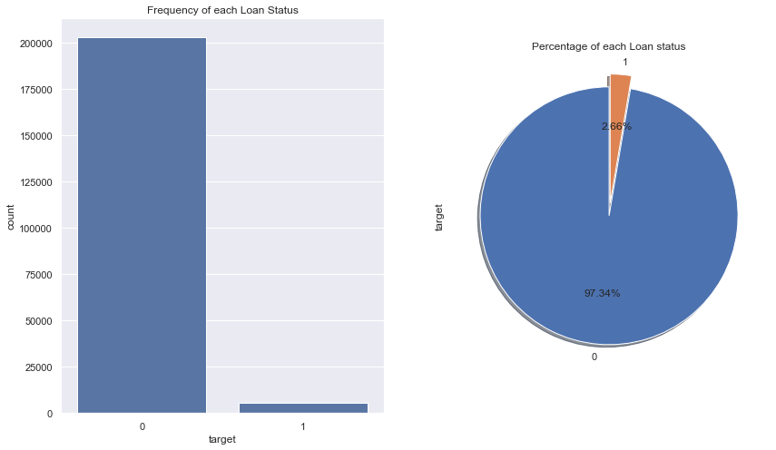

```python
 sns.set_theme()
fig, axs = plt.subplots(1,2,figsize=(14,8))
sns.countplot(x='target',data=final_df,ax=axs[0])
axs[0].set_title("Frequency of each Loan Status")
final_df.target.value_counts().plot(x=None,y=None, kind='pie', ax=axs[1],shadow =True,explode = (0, 0.1,),autopct='%1.2f%%',startangle=90 )
axs[1].set_title("Percentage of each Loan status")
plt.show()
```

The target variable exhibits a massive class imbalance, with one class representing 97.34% of the data and the other class representing 2.66%.

# 3. Exploratory data analysis (EDA)

## 3.1 Checking missing values

We'll count the number of missing values in each column.

```python
final_df.isnull().sum()
```

```
loanId                                  0
anon_ssn                                0
payFrequency                            0
apr                                     0
applicationDate                         0
originatedDate                          0
nPaidOff                               82
loanStatus                              0
loanAmount                              0
originallyScheduledPaymentAmount        0
state                                   0
leadType                                0
leadCost                                0
fpStatus                                0
clearfraudscore                     39352
installmentIndex                        2
isCollection                            2
paymentDate                             2
principal                               2
fees                                    2
paymentAmount                           2
paymentStatus                           2
target                                  0
dtype: int64
```

We need to handle missing values in nPaidOff, clearFraudScore, and paymentStatus columns. I'll drop rows with null values in installmentIndex, isCollection, paymentDate, principal, fees, and paymentAmount columns.

## 3.2 Check duplicate values

```python
### Check duplicate records

n_duplicates = final_df.drop(labels=["loanId"], axis=1).duplicated().sum()
print(f"There are {n_duplicates} duplicates in your dataset.")
```

```
There are 0 duplicates in your dataset.
```

## 3.3 EDA features vs default and not default

### default and not default percentage on each state compared to total loan amount

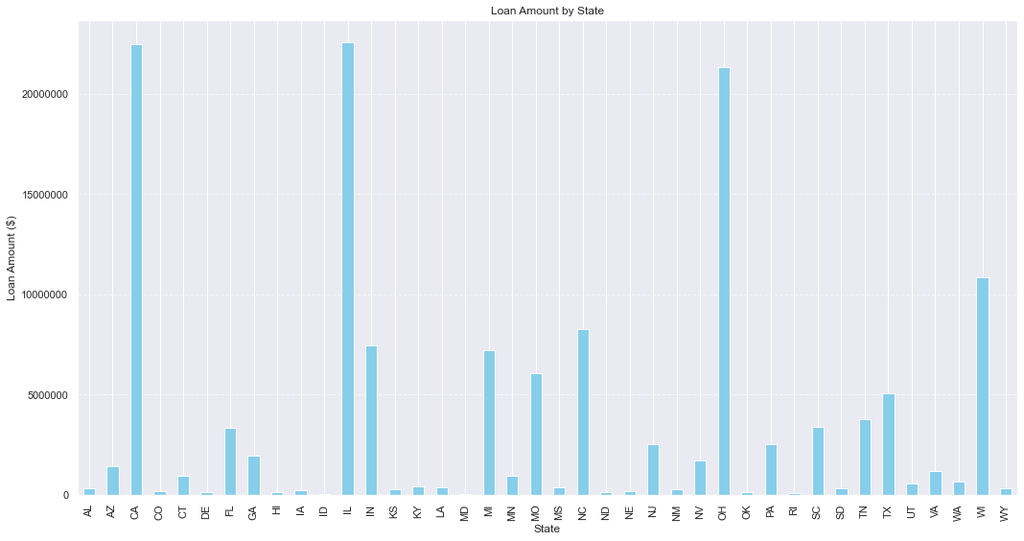

```python
# Group by state and calculate the total loan amount
state_loan_amount = final_df.groupby('state')['loanAmount'].sum()

# Plotting
plt.figure(figsize=(15, 8))
state_loan_amount.plot(kind='bar', color='skyblue')
plt.title('Loan Amount by State')
plt.xlabel('State')
plt.ylabel('Loan Amount ($)')
plt.xticks(rotation=90)
plt.ticklabel_format(style='plain', axis='y')
plt.grid(axis='y', linestyle='--', alpha=0.7)
plt.tight_layout()
plt.show()
```

```python
#group by 'state' and 'target'
result_table = final_df.groupby(['state','target'])['target'].agg({'size'}).unstack()

#calculating row wise sum
row_sum = result_table.sum(axis=1)

#calculating percentages
result_table_percent = (result_table.div(row_sum, axis=0) * 100).round(2)

result_table_percent
```

| target state | size 0 | size 1 |
| --- | --- | --- |
| AL | 100.00 | NaN |
| AZ | 98.79 | 1.21 |
| CA | 95.93 | 4.07 |
| CO | 100.00 | NaN |
| CT | 100.00 | NaN |
| DE | 100.00 | NaN |
| FL | 100.00 | NaN |
| GA | 100.00 | NaN |
| HI | 100.00 | NaN |
| IA | 100.00 | NaN |
| ID | 100.00 | NaN |
| IL | 96.06 | 3.94 |
| IN | 97.41 | 2.59 |
| KS | 96.88 | 3.12 |
| KY | 98.49 | 1.51 |
| LA | 98.13 | 1.87 |
| MD | 100.00 | NaN |
| MI | 97.79 | 2.21 |
| MN | 100.00 | NaN |
| MO | 95.89 | 4.11 |
| MS | 97.90 | 2.10 |
| NC | 99.36 | 0.64 |
| ND | 100.00 | NaN |
| NE | 100.00 | NaN |
| NJ | 97.90 | 2.10 |
| NM | 100.00 | NaN |
| NV | 97.64 | 2.36 |
| OH | 97.30 | 2.70 |
| OK | 100.00 | NaN |
| PA | 99.65 | 0.35 |
| RI | 100.00 | NaN |
| SC | 99.61 | 0.39 |
| SD | 100.00 | NaN |
| TN | 95.14 | 4.86 |
| TX | 98.54 | 1.46 |
| UT | 89.04 | 10.96 |
| VA | 94.98 | 5.02 |
| WA | 100.00 | NaN |
| WI | 97.26 | 2.74 |
| WY | 100.00 | NaN |

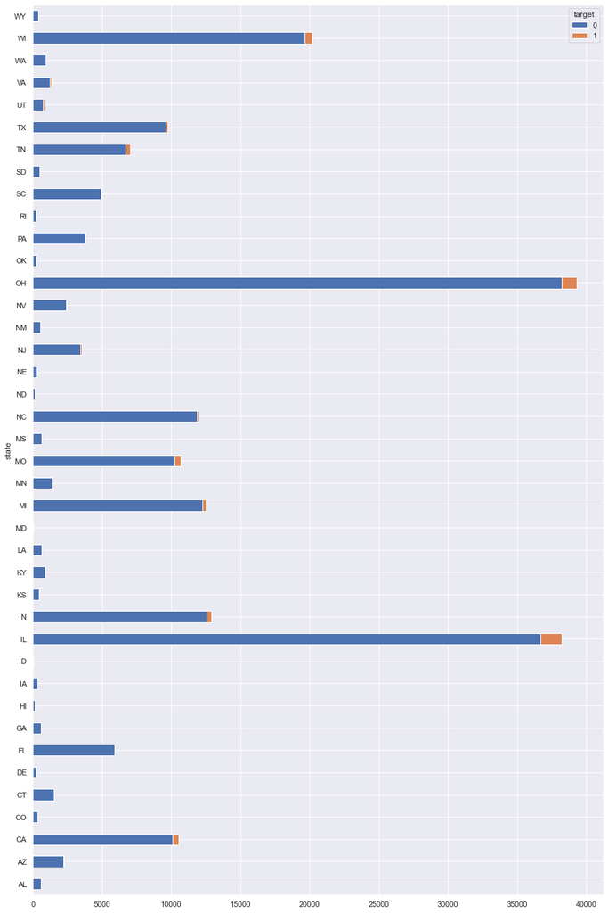

```python
pd.crosstab(index=final_df['state'],columns=final_df['target'].sort_values(ascending=False)).plot(kind='barh',stacked=True,figsize=(15,24))
```

It seems like the highest number of total loans are taken from states CA, IL, and OH. The graph above displays the proportion of default and non-default loans for each state.

### isCollection status vs. LoanStatus

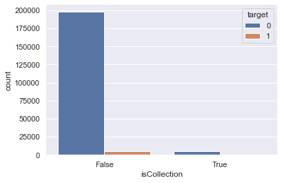

```python
sns.countplot(x='isCollection',hue='target',data=final_df)
sns.despine(top=True,right=True,left=True) # to remove side line from graph
```

It seems that for loans with a custom-made collection plan, there are no defaults observed, whereas loans with the original payment plan have some default cases.

### Apr distribution by Loan Status

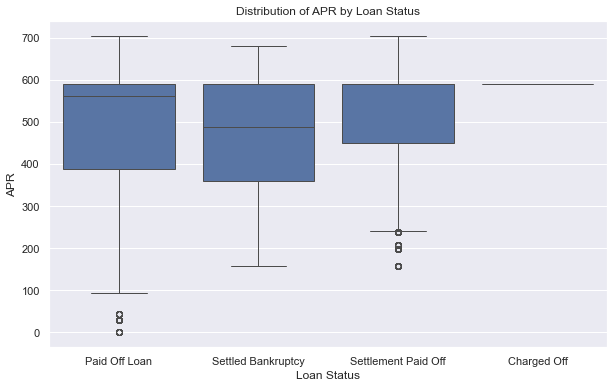

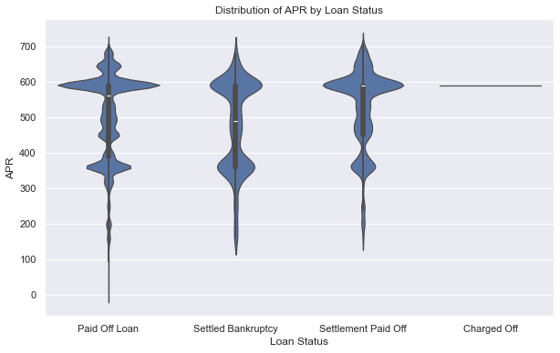

```python
# Create a box plot
plt.figure(figsize=(10, 6))
sns.boxplot(x='loanStatus', y='apr', data=final_df)
plt.title('Distribution of APR by Loan Status')
plt.xlabel('Loan Status')
plt.ylabel('APR')
plt.show()

# Create a violin plot
plt.figure(figsize=(10, 6))
sns.violinplot(x='loanStatus', y='apr', data=final_df)
plt.title('Distribution of APR by Loan Status')
plt.xlabel('Loan Status')
plt.ylabel('APR')
plt.show()
```

It appears that the APR doesn't significantly influence the loan status, as all loan statuses exhibit similar APR values.

### Payment frequency analysis

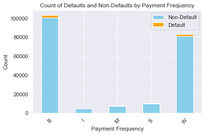

```python
# Group by payment frequency and count defaults and non-defaults
default_counts_by_frequency = final_df.groupby(['payFrequency', 'target']).size().unstack(fill_value=0)

# Plotting the distribution
plt.figure(figsize=(20, 10))
default_counts_by_frequency.plot(kind='bar', stacked=True, color=['skyblue', 'orange'])
plt.title('Count of Defaults and Non-Defaults by Payment Frequency')
plt.xlabel('Payment Frequency')
plt.ylabel('Count')
plt.xticks(rotation=45)  # Rotate x-axis labels for better readability
plt.legend(['Non-Default', 'Default'])
plt.grid(axis='y', linestyle='--', alpha=0.7)
plt.tight_layout()
plt.show()
```

## No of loans vs. Total paid off by client

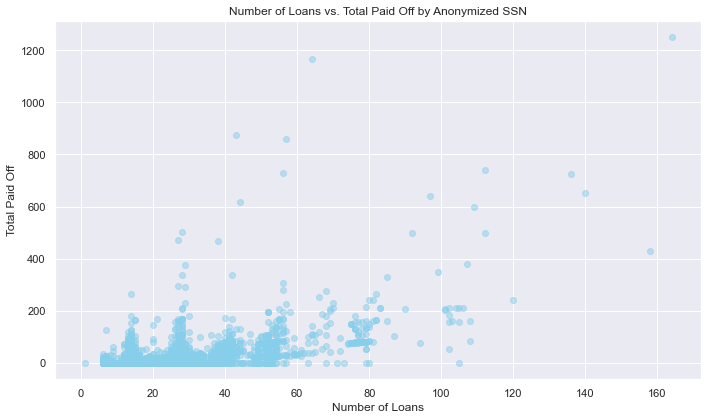

```python
# Group by anon_ssn and calculate the count of loans and sum of nPaidOff
ssn_summary = final_df.groupby('anon_ssn').agg({'loanId': 'count', 'nPaidOff': 'sum'}).reset_index()
ssn_summary.rename(columns={'loanId': 'Number of Loans', 'nPaidOff': 'Total Paid Off'}, inplace=True)

# Plotting
plt.figure(figsize=(10, 6))
plt.scatter(ssn_summary['Number of Loans'], ssn_summary['Total Paid Off'], color='skyblue', alpha=0.5)
plt.title('Number of Loans vs. Total Paid Off by Anonymized SSN')
plt.xlabel('Number of Loans')
plt.ylabel('Total Paid Off')
plt.grid(True)
plt.tight_layout()
plt.show()
```

### Payment amount vs. scheduled amount

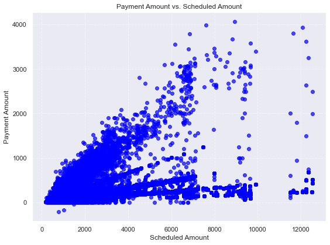

```python
plt.figure(figsize=(8, 6))
plt.scatter(final_df['originallyScheduledPaymentAmount'], final_df['paymentAmount'], color='blue', alpha=0.7)
plt.title('Payment Amount vs. Scheduled Amount')
plt.xlabel('Scheduled Amount')
plt.ylabel('Payment Amount')
plt.grid(True, linestyle='--', alpha=0.5)
plt.tight_layout()
plt.show()
```

We can observe that there are many instances of underpayments despite the scheduled amount.

### Installment Index analysis

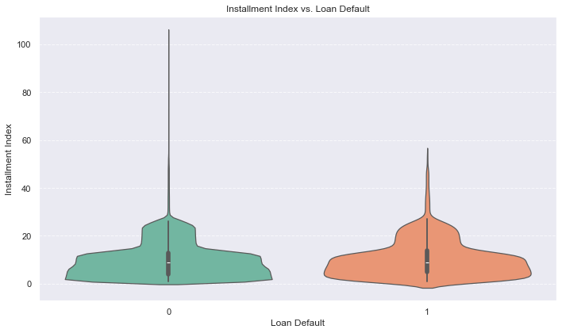

```python
plt.figure(figsize=(10, 6))
sns.violinplot(x='target', y='installmentIndex', data=final_df, palette='Set2')
plt.title('Installment Index vs. Loan Default')
plt.xlabel('Loan Default')
plt.ylabel('Installment Index')
plt.grid(axis='y', linestyle='--', alpha=0.7)
plt.tight_layout()
plt.show()
```

### Trend of numerical features with the target variable

```python
numeric_ls=list(final_df.describe().columns.to_list())
```

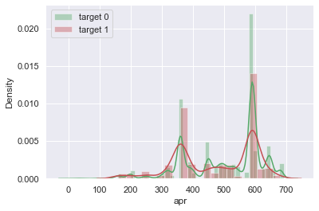

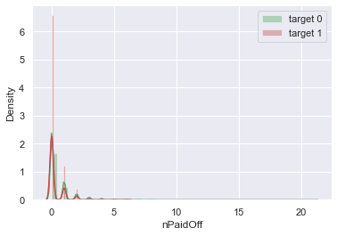

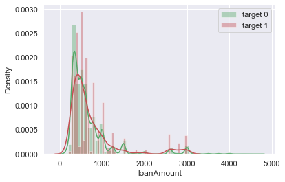

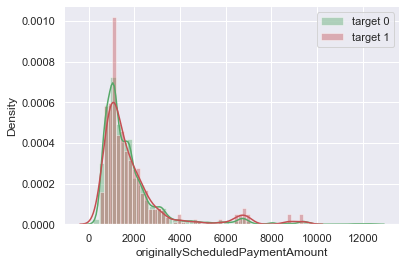

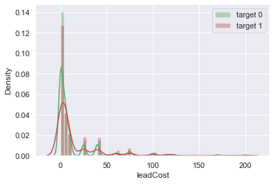

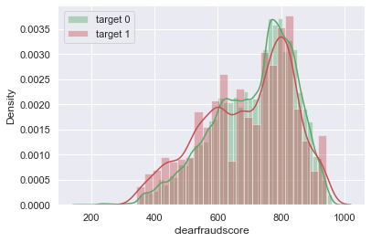

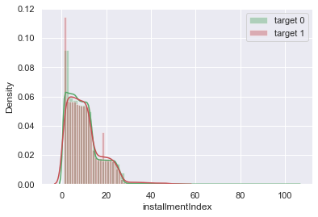

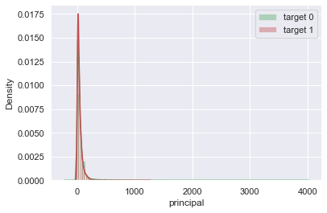

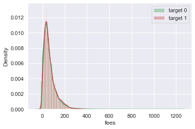

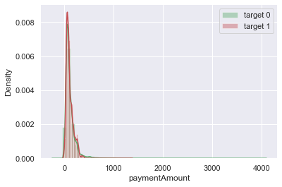

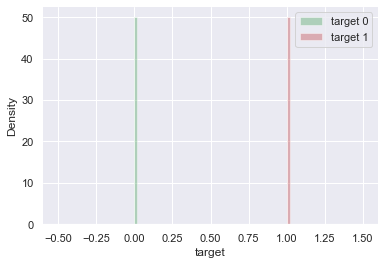

```python
for col in numeric_ls:
    sns.distplot(final_df[final_df['target'] == 0][col], color='g', label='target 0')
    sns.distplot(final_df[final_df['target'] == 1][col], color='r', label='target 1')
    sns.despine(top=True, right=True, left=True)  # to remove side line from graph
    plt.legend()
    plt.show()
```

## 3.4 Correlation heatmap

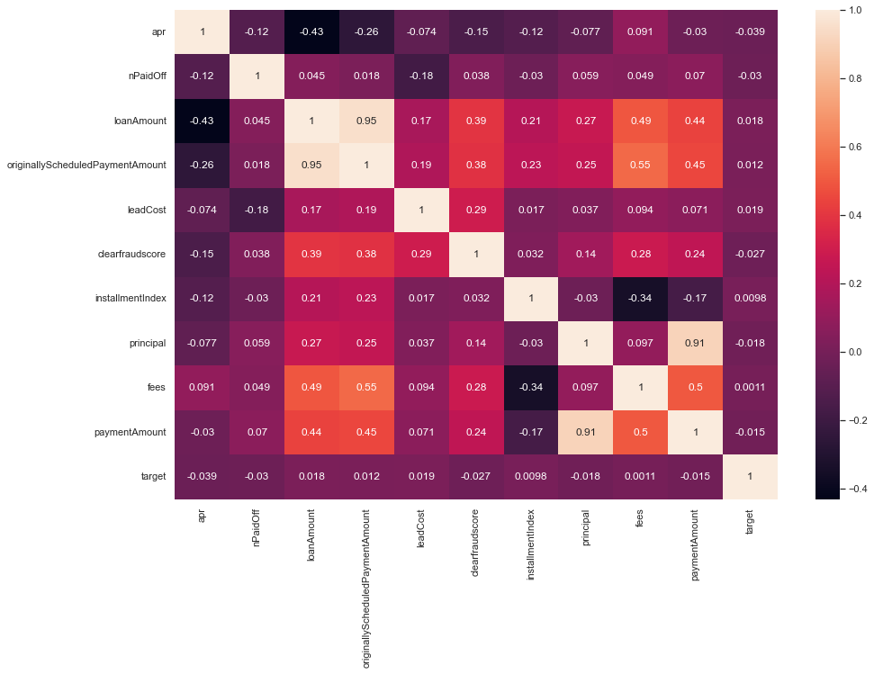

```python
sns.set_palette(sns.color_palette("Set2", 8))
plt.figure(figsize=(15,10))
sns.heatmap(final_df.corr(),annot=True)
plt.show()
```

The loanAmount and originallyScheduledPaymentAmount show a high correlation of 0.95, while Principal and paymentAmount exhibit a correlation of 0.91. We're not dropping any of these features at the moment. However, if our model starts producing unstable predictions, we may revisit this decision and drop one of these columns.

## 3.5 Categorical data analysis

```python
categorical_ls=list(set(final_df.columns.to_list())-set(final_df.describe().columns.to_list()))
```

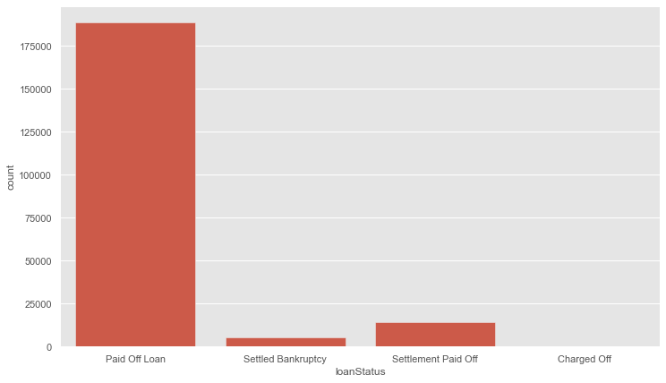

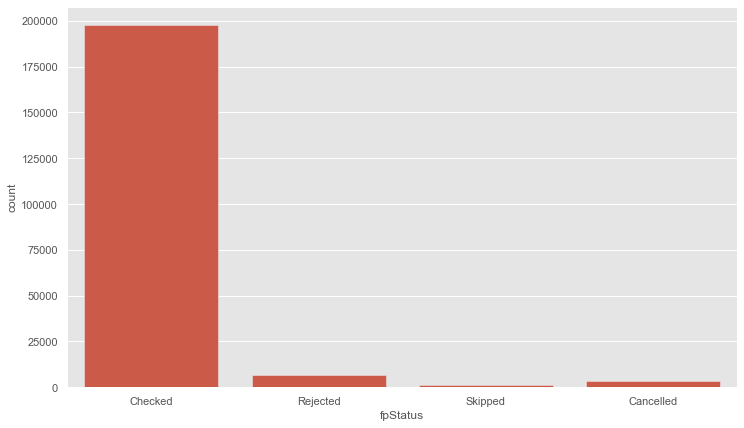

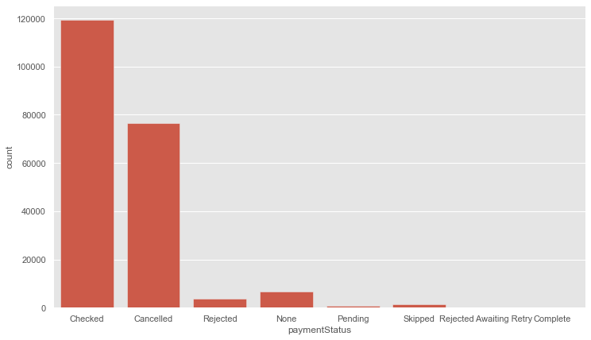

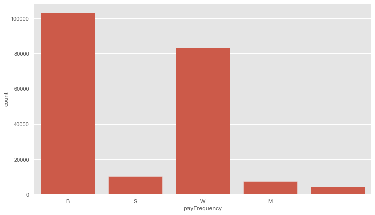

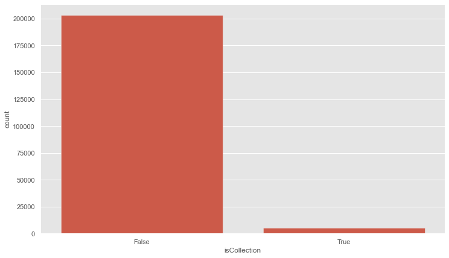

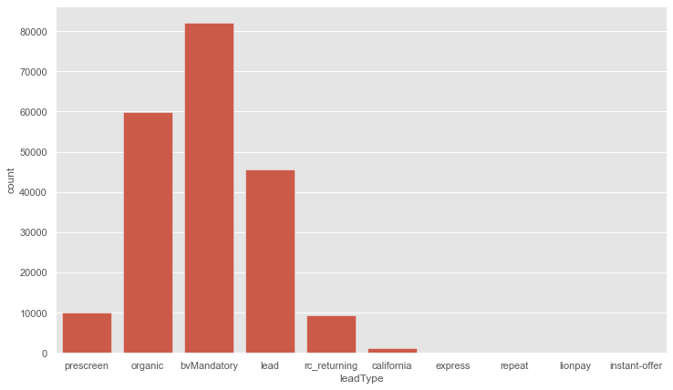

```python
plt.style.use('ggplot')
for column in categorical_ls:
  if final_df[column].nunique() < 25:
    plt.figure(figsize=(12,7))
    sns.countplot(x=column,data=final_df[categorical_ls])
    #plt.legend()
    plt.show()
```

# 4. Data Preprocessing

## 4.1 Handling missing values

### Plot histogram of clearfraudscore

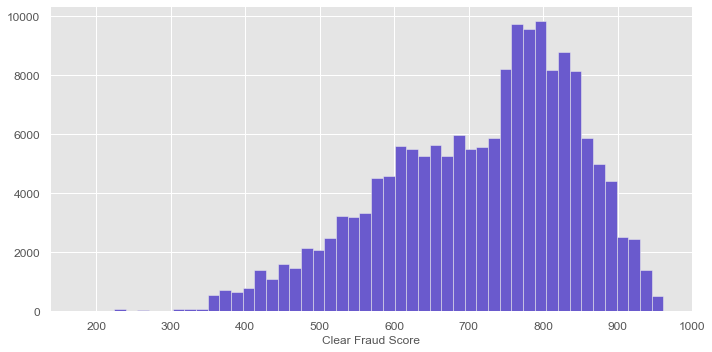

```python
plt.figure(figsize=(10, 5))
final_df['clearfraudscore'].plot(kind='hist', bins=50, color='slateblue')
plt.xlabel('Clear Fraud Score', fontsize=12)
plt.ylabel('')
plt.xticks(fontsize=12)
plt.yticks(fontsize=12)
plt.tight_layout()
plt.show()
```

Plot shows a skewness in data therefore we will be using the median of data to fill missing values in clearfraudscore column

### Plot histogram of nPaidOff

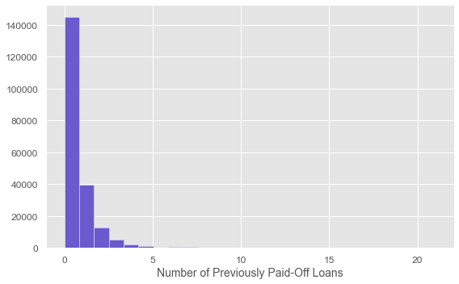

```python
# Plot histogram of nPaidOff
plt.figure(figsize=(8, 5))
final_df['nPaidOff'].plot(kind='hist', bins=25, color='slateblue')
plt.xlabel('Number of Previously Paid-Off Loans', fontsize=14)
plt.ylabel('')
plt.xticks(fontsize=12)
plt.yticks(fontsize=12)
plt.tight_layout()
plt.show()
```

data is heavily concetrated near O therefore we will use mode to fill nPaidOff missing values

### Plot bar plot of paymentStatus

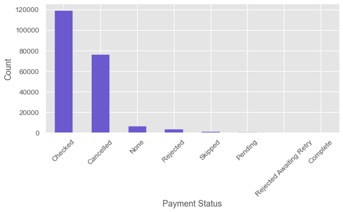

```python
plt.figure(figsize=(8, 5))
final_df['paymentStatus'].value_counts().plot(kind='bar', color='slateblue')
plt.xlabel('Payment Status', fontsize=14)
plt.ylabel('Count', fontsize=14)
plt.xticks(fontsize=12, rotation=45)
plt.yticks(fontsize=12)
plt.tight_layout()
plt.show()
```

```python
# Fill missing values

final_df.loc[df['clearfraudscore'].isna(), 'clearfraudscore'] = df['clearfraudscore'].median()
final_df.loc[df['nPaidOff'].isna(), 'nPaidOff'] = df['nPaidOff'].mode()[0]
final_df.fillna({'paymentStatus': 'Missing'}, inplace=True)
```

```python
# Drop rows with missing values
final_df.dropna(subset=['installmentIndex'], inplace=True)
```

Dropping null rows based on the installmentIndex column also resulted in the automatic removal of null rows in other columns.